# Testy hypotez pre parametre normálneho rozdelenia

Jozef Barčák

2026-10-08

```r
library(latexpdf) #pouzitie tex-u, grafy
library(latex2exp) # bezne vzorce lat-tex
```

# Testy hypotez pre parametre normalneho rozdelenia

# Testy pre strednu hodnotu $\mu$ a $\sigma$ pozname

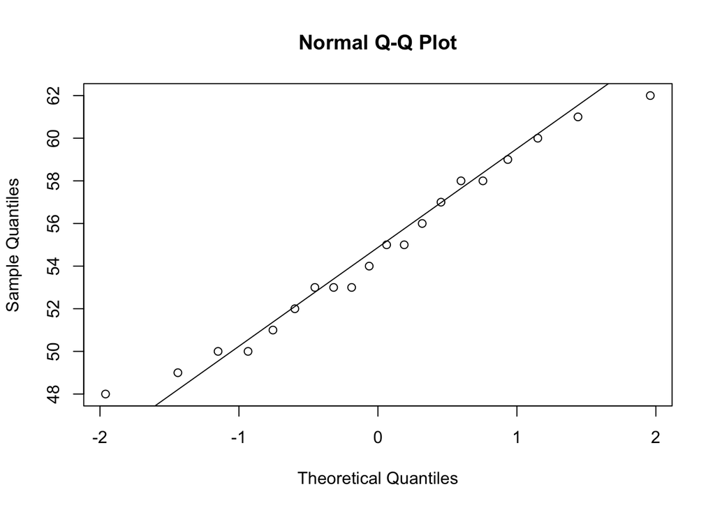

```r
cas <- c(48, 55, 51, 62, 53, 58, 60, 50, 49, 57, 52, 61, 54, 56, 59,53,
         50, 58, 55, 53)
qqnorm(cas) #kvantil kvantil graf
qqline(cas)#pridat ciaru
```

Shapiro wilk test

```r
shapiro.test(cas)
```

```
##
##  Shapiro-Wilk normality test
##
## data:  cas
## W = 0.96958, p-value = 0.7459
```

P hodnota = 0.74>0.05, nezamietame hypotezu o normalite dat Pozname disperziu, teda Z test kniznica DescTools

```r
library(DescTools)
ZTest(cas,mu=58,sd_pop=3.8)
```

```
##
##  One Sample z-test
##
## data:  cas
## z = -3.8837, Std. Dev. Population = 3.8, p-value = 0.0001029
## alternative hypothesis: true mean is not equal to 58
## 95 percent confidence interval:
##  53.03461 56.36539
## sample estimates:
## mean of x
##      54.7
```

```r
ZTest(cas,mu=58,sd_pop=3.8)$p.value
```

```
## [1] 0.0001028801
```

```r
broom::tidy(ZTest(cas,mu=58,sd_pop=3.8))
```

```
## # A tibble: 1 × 8
##   estimate statistic  p.value parameter conf.low conf.high method    alternative
##      <dbl>     <dbl>    <dbl>     <dbl>    <dbl>     <dbl> <chr>     <chr>
## 1     54.7     -3.88 0.000103       3.8     53.0      56.4 One Samp… two.sided
```

Nová Hypoteza: Otazka v skutocnosti znela, ci zotrvaju na stranke aspon 58s.
$$H_0 \quad \mu=58 \qquad
\mu>58$$

```r
ZTest(cas, mu=58,alternative="g",sd_pop=3.8)
```

```
##
##  One Sample z-test
##
## data:  cas
## z = -3.8837, Std. Dev. Population = 3.8, p-value = 0.9999
## alternative hypothesis: true mean is greater than 58
## 95 percent confidence interval:
##  53.30236      Inf
## sample estimates:
## mean of x
##      54.7
```

Phodnota=0.99>0.05, nezamietame $H_0$, nie je pravda, ze zotrvaju viac ako 58 sekund Ak by sme testovali napriklad na hladine vyznamnosti $\alpha=0.1$, aj tak rozhodujeme : ak Phodnota >0.1, tak nezamietame nulovu hypotezu Test graficky, ten prvy test

[figure not shown]

```r
plot(function(x)dnorm(x,0,1),from=3, to=3, main = TeX("Text pre $\\mu$"),
     ylab="hustota")
q <- qnorm(0.975, 0.1)#kvantil normalneho rozdelenia, hranica
z <- -0.35#statistika z vystupu testu
abline(v=z,col="blue")
abline(v=q,col="red")
abline(v=-q,col="red")
```

# Test pre $\mu$ ak $\sigma$ nepozname

Testujeme testy z predosleho prikladu za predpokladu, $\sigma$ nepozname

```r
t.test(cas,mu=55)
```

```
##
##  One Sample t-test
##
## data:  cas
## t = -0.32682, df = 19, p-value = 0.7474
## alternative hypothesis: true mean is not equal to 55
## 95 percent confidence interval:
##  52.77871 56.62129
## sample estimates:
## mean of x
##      54.7
```

```r
t.test(cas,mu=55)$p.value
```

```
## [1] 0.7473805
```

phodnota> 0.05 nezamietame $H_O$ tvrdenie plati. Druha hypoteza

```r
t.test(cas,mu=58,alternative="g")
```

```
##
##  One Sample t-test
##
## data:  cas
## t = -3.595, df = 19, p-value = 0.999
## alternative hypothesis: true mean is greater than 58
## 95 percent confidence interval:
##  53.11274      Inf
## sample estimates:
## mean of x
##      54.7
```

Phodnota>0.05, nezamietame $H_O$, teda nie je pravda, ze vydrzia viac ako 58 sekúnd # Plnicka jablkovej stavy

Firma predava jablkovu stavu v 0.5l baleniach. Plniaca linka presla servisom. Potom sme namerali tieto hodnoty plneneho objemu v ml. Na hladine vyznamnosti $\alpha=0.1$, testujte hypotezu, ze linka je dobre nastavena

$$H_O \quad \mu=500 \qquad H_1 \quad \mu
\neq 500$$

```r
jablko <- c(499.2,496.8,502.1,498.5,501,503,500.7,
            501.5,501.8,499.1,500.9,502.2,501.7, 500.4,
            500.2,501.1,499.9,500.2,501.1,500.8,499.3)

shapiro.test(jablko)#normalne rozdelene, ak
```

```
##
##  Shapiro-Wilk normality test
##
## data:  jablko
## W = 0.96169, p-value = 0.5507
```

```r
t.test(jablko,mu=500)# nemusim dat hladinu vyznamnosti
```

```
##
##  One Sample t-test
##
## data:  jablko
## t = 1.7663, df = 20, p-value = 0.09261
## alternative hypothesis: true mean is not equal to 500
## 95 percent confidence interval:
##  499.9009 501.1944
## sample estimates:
## mean of x
##  500.5476
```

Kedze $\alpha=0.1$ a Phodnota=0.09<0.1 zamietame H_0 Ak by bola 0.05, .09>0:05 tak by sme nezamietali

# Zlozene alternativy

Firma, ktora vyraba baterie do netebookov tvrdí, ze jednu vyrobí v tom procese do 13 minút. Overte toto tvrdenie, ak mate k dispozicii 20 merani, $\alpha=0.05$. Stanovte spravne nulovu a alternativnu hypotezu

```r
baterie <- c(12,19,16,13,15,12,14,20,15,19,17,20,
             13,9,11,20,12,19,8,13)
shapiro.test(baterie)#normalne rozdelene
```

```
##
##  Shapiro-Wilk normality test
##
## data:  baterie
## W = 0.93108, p-value = 0.1619
```

$$H_O \quad \mu=13 \qquad H_1 \quad
\mu<13$$

```r
t.test(baterie, mu=13,alternative="l")
```

```
##
##  One Sample t-test
##
## data:  baterie
## t = 2.2006, df = 19, p-value = 0.9798
## alternative hypothesis: true mean is less than 13
## 95 percent confidence interval:
##      -Inf 16.30361
## sample estimates:
## mean of x
##     14.85
```

phodnota=0.97>0.05, nezamierame nulovu hypotezu, neprijimame alternativy, trva mu to viac, odhad strednej hodnoty je 14.8$

Vyrobca tvrdi, ze baterky do elekronickych pristrojov vydrzia aspon 19 hodin nepretrzitej prevádzky. Testujte, ak máme k dispozicii dátový súbor baterie1. Ak $\alpha$ dalej neuvedieme, bude 0.05.

```r
baterie1<- c(18.2,19.6,18.6,19.4,17,18.5,18,18.4,19,
             18,17.9,18.1)
shapiro.test(baterie1)#normalne rozdelene
```

```
##
##  Shapiro-Wilk normality test
##
## data:  baterie1
## W = 0.95612, p-value = 0.7274
```

$$H_O \quad \mu=19 \qquad H_1 \quad
\mu>19$$

```r
t.test(baterie1, mu=19, alternative="g")
```

```
##
##  One Sample t-test
##
## data:  baterie1
## t = -2.9777, df = 11, p-value = 0.9937
## alternative hypothesis: true mean is greater than 19
## 95 percent confidence interval:
##  18.02478      Inf
## sample estimates:
## mean of x
##  18.39167
```

Phodnota>0.05, nezamietame nulovu hypotezu nevydrzia viac ako 19 hodin

```r
t.test(baterie1,mu=19,alternative="l")#len ci dojde k sporu
```

```
##
##  One Sample t-test
##
## data:  baterie1
## t = -2.9777, df = 11, p-value = 0.006285
## alternative hypothesis: true mean is less than 19
## 95 percent confidence interval:
##      -Inf 18.75856
## sample estimates:
## mean of x
##  18.39167
```

Tu HO zamietame prijme H0, co nie je spor Vydrzia menej ako 19

Priklad

Pizzeria ABC ma na letaku uveden, ze pizzu dovezu do 30 min. Casy dodavok su v datovom subore pizza. Testujte na hladine vyznamnosti $\aplha=0.05$. Vyslovte zaver

```r
pizza <- c(27,25,30,28,29,24,30,26,28,32,
           24,32,31,29,28,29,35,34,30,31,18,22)

shapiro.test(pizza)# overenie normality
```

```
##
##  Shapiro-Wilk normality test
##
## data:  pizza
## W = 0.96091, p-value = 0.5078
```

Ak Phodnota>0.05, nezamietame hypotezu o normalite dat $\sigma$ nepozname, teda t test
$$H_0 \quad \mu=30 \qquad H_1 \quad
\mu<30$$

```r
t.test(pizza, mu=30, alternative="l")
```

```
##
##  One Sample t-test
##
## data:  pizza
## t = -2.0426, df = 21, p-value = 0.02692
## alternative hypothesis: true mean is less than 30
## 95 percent confidence interval:
##      -Inf 29.72782
## sample estimates:
## mean of x
##  28.27273
```

```r
t.test(pizza, mu=30, alternative="l")$p.value
```

```
## [1] 0.02692272
```

Ak Phodnota<0.05: zamietame $H_0$, prijimame $H_1$, pizzu dovezu v priemere do 30 minut, tvrdenie na letaku plati. Ak Phodnota>0.05: nezamietame $H_0$, nepreukazalo sa, ze pizzu dovezu do 30 minut. #testy pre disperziu normalneho rozdelenia

V prvom priklade sme tvrdili, ze $\sigma=3.8$, datovy subor cas. Na hladine vyznamnosti $\aplha=0.05$ overte toto tvrdenie

```r
EnvStats::varTest(cas,sigma.squared = 3.8^2)
```

```
## $statistic
## Chi-Squared
##    22.17452
##
## $parameters
## df
## 19
##
## $p.value
## [1] 0.5513144
##
## $estimate
## variance
## 16.85263
##
## $null.value
## variance
##    14.44
##
## $alternative
## [1] "two.sided"
##
## $method
## [1] "Chi-Squared Test on Variance"
##
## $data.name
## [1] "cas"
##
## $conf.int
##       LCL       UCL
##  9.746646 35.951205
## attr(,"conf.level")
## [1] 0.95
##
## attr(,"class")
## [1] "htestEnvStats"
```

```r
EnvStats::varTest(cas,sigma.squared = 3.8^2)$p.value
```

```
## [1] 0.5513144
```

Nezamietame $H_0

Dvojvyberove testy

Merania idu v pare, vytvorime diferencie a zie zmysluplne testujeme Su dane casy v sekundach, pred a po, pocas ktorych riesili ziaci kontrolne ulohy pred a po cviceniach z pamatoveho pocitania. Zlepsili cvicenia schopnost ziakov riesit ulohy?

$$H_0 \quad \mu_{pred}-\mu_{po}=0 \qquad
H_1 \mu_{pred}-\mu_{po}>0$$

```r
pred <- c(87,61,98,90,93,74,83,72,81,75,83)
po <- c(50,45,79,90,88,65,52,79,84,61,52)
d <- pred-po
shapiro.test(d)
```

```
##
##  Shapiro-Wilk normality test
##
## data:  d
## W = 0.95142, p-value = 0.6621
```

```r
t.test(d,alternative = "g")
```

```
##
##  One Sample t-test
##
## data:  d
## t = 3.1128, df = 10, p-value = 0.005504
## alternative hypothesis: true mean is greater than 0
## 95 percent confidence interval:
##  5.77245     Inf
## sample estimates:
## mean of x
##  13.81818
```

Phodnota=0.005<0.05 zamietame H0 teda prijimame H1, zlepsili sa

```r
t.test(pred,po,alternative="g", paired=T)
```

```
##
##  Paired t-test
##
## data:  pred and po
## t = 3.1128, df = 10, p-value = 0.005504
## alternative hypothesis: true mean difference is greater than 0
## 95 percent confidence interval:
##  5.77245     Inf
## sample estimates:
## mean difference
##        13.81818
```